# Analysis of longitudinal data

*This week I have covered analysis of longitudinal data and data wrangling exercise.*

```r
date()
```

```
## [1] "Sun Dec 12 17:25:22 2021"
```

#### Longitudinal data :

- Many studies in the behavioral sciences involve several measurement or observations of the response variable of interest on each subject in the study.
- For example, the response variable may be measured under a number of different occasions over time.
- Such data are called longitudinal data.

### 0. Information of RATS and BPRS dataset

#### RATS Dataset:

- RATS data is extracted from a nutrition study conducted in three groups of rats (Crowder and Hand, 1990).
- The three groups were put on different diets, and each animal’s body weight (grams) was recorded repeatedly (approximately weekly, except in week seven when two recordings were taken) over a 9-week period.
- The focus here is to check whether the growth profiles of the three groups differ.

#### BPRS Dataset:

- In this BPRS dataset, 40 male subjects were randomly assigned to one of two treatment groups and each subject was rated on the brief psychiatric rating scale (BPRS) measured before treatment began (week 0) and then at weekly intervals for eight weeks.
- The BPRS assesses the level of 18 symptom constructs such as hostility, suspiciousness, hallucinations and grandiosity; each of these is rated from one (not present) to seven (extremely severe).
- The scale is used to evaluate patients suspected of having schizophrenia.

```r
date()
```

```
## [1] "Sun Dec 12 17:25:22 2021"
```

```r
# packages in use
library(dplyr)
library(ggplot2)
library(tidyr)
```

```r
bprs = read.csv("data/BPRSL.csv", as.is = TRUE, header = TRUE, row.names = NULL)
rats = read.csv("data/RATSL.csv", as.is = TRUE, header = TRUE, row.names = NULL)

str(bprs)
```

```
## 'data.frame':    360 obs. of  5 variables:
##  $ treatment: int  1 1 1 1 1 1 1 1 1 1 ...
##  $ subject  : int  1 2 3 4 5 6 7 8 9 10 ...
##  $ weeks    : chr  "week0" "week0" "week0" "week0" ...
##  $ bprs     : int  42 58 54 55 72 48 71 30 41 57 ...
##  $ week     : int  0 0 0 0 0 0 0 0 0 0 ...
```

```r
str(rats)
```

```
## 'data.frame':    176 obs. of  5 variables:
##  $ ID    : int  1 2 3 4 5 6 7 8 9 10 ...
##  $ Group : int  1 1 1 1 1 1 1 1 2 2 ...
##  $ WD    : chr  "WD1" "WD1" "WD1" "WD1" ...
##  $ Weight: int  240 225 245 260 255 260 275 245 410 405 ...
##  $ Time  : int  1 1 1 1 1 1 1 1 1 1 ...
```

We should factor the factorial variables again.

```r
# Factor variables ID and Group
rats$ID <- factor(rats$ID)
rats$Group <- factor(rats$Group)
str(rats)
```

```
## 'data.frame':    176 obs. of  5 variables:
##  $ ID    : Factor w/ 16 levels "1","2","3","4",..: 1 2 3 4 5 6 7 8 9 10 ...
##  $ Group : Factor w/ 3 levels "1","2","3": 1 1 1 1 1 1 1 1 2 2 ...
##  $ WD    : chr  "WD1" "WD1" "WD1" "WD1" ...
##  $ Weight: int  240 225 245 260 255 260 275 245 410 405 ...
##  $ Time  : int  1 1 1 1 1 1 1 1 1 1 ...
```

```r
# # Factor treatment & subject
# bprs$treatment <- factor(bprs$treatment)
# bprs$subject <- factor(bprs$subject)
# str(bprs)
```

## Part 1: Analyses of Chapter 8 of MABS using the RATS data.

### Graphical overview of group differences of Non-Standardized data

The data is based on a study conducted in three groups of rats and observed weights over time. Let’s check the group-wise weight differences of rats.

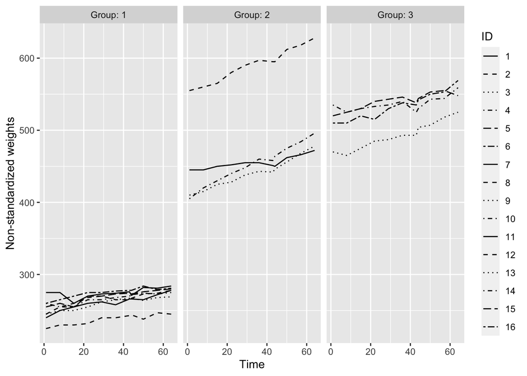

```r
ggplot(rats, aes(x = Time, y = Weight, linetype = ID)) +
  geom_line() +
  scale_linetype_manual(values = rep(1:10, times=4)) +
  facet_grid(. ~Group, labeller = label_both) +
  scale_y_continuous(limits = c(min(rats$Weight), max(rats$Weight)), name = "Non-standardized weights")
```

### Interpretation of results

We can Immediately notice that,

- **Group-1** rats have gained lower weights with compared to **Group-2** and **Group-3** .
- The rats in **Group-2** and **Group-3** achieved almost similar weights.

### Standardized data

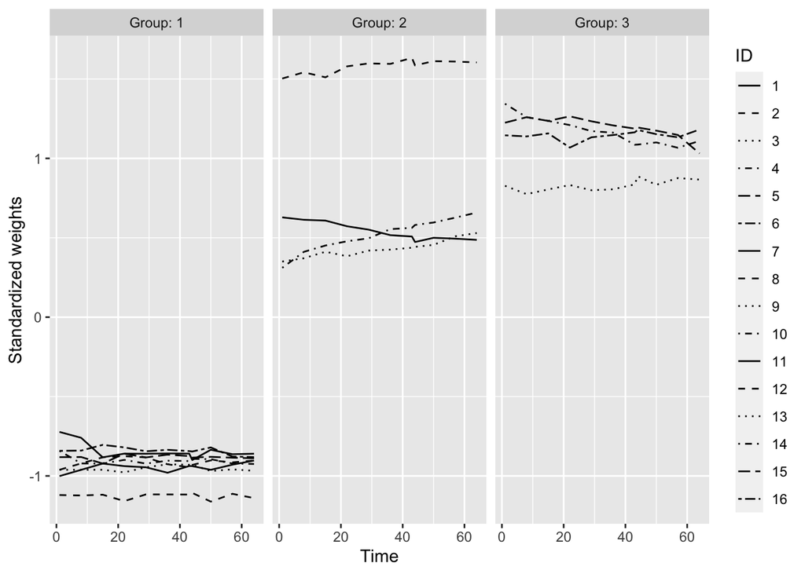

```r
# Standardize
rats <- rats %>%
  group_by(Time) %>%
  mutate(stdWeight = (Weight - mean(Weight))/sd(Weight) ) %>%
  ungroup()

# Plot  with the standardized data
ggplot(rats, aes(x = Time, y = stdWeight, linetype = ID)) +
  geom_line() +
  scale_linetype_manual(values = rep(1:10, times=4)) +
  facet_grid(. ~ Group, labeller = label_both) +
  scale_y_continuous(name = "Standardized weights")
```

### Interpretation of results

Even after standardization of weights, we can Immediately notice that,

- **Group-1** rats have gained lower weights with compared to **Group-2** and **Group-3** .
- The rats in **Group-2** and **Group-3** achieved almost similar weights.

### Summary Measure Analysis of Longitudinal Data

- The summary measure method operates by transforming the repeated measurements made on each individual in the study into a single value that captures some essential feature of the individual’s response over time.
- The key step to a successful summary measure analysis of longitudinal data is the choice of a relevant summary measure.

### Mean response profiles

```r
rats_l <- rats %>%
  group_by(Group, Time) %>%
  summarise(mean = mean(Weight), se = sd(Weight) /  sqrt(n())) %>%
  ungroup()
```

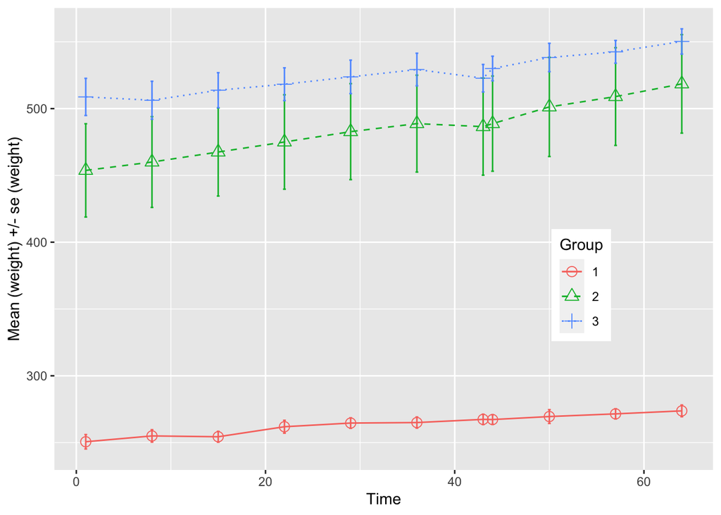

```r
# Plot the mean profiles
ggplot(rats_l , aes(x = Time, y = mean, linetype = Group, shape = Group, col = Group)) +
  geom_line() +
  scale_linetype_manual(values = c(1,2,3)) +
  geom_point(size=3) +
  scale_shape_manual(values = c(1,2,3)) +
  geom_errorbar(aes(ymin=mean-se, ymax=mean+se, linetype="1"), width=0.3) +
  theme(legend.position = c(0.8,0.4)) +
  scale_y_continuous(name = "Mean (weight) +/- se (weight)")
```

### Interpretation of results : Mean response profiles

We can Immediately notice that,

- Mean weights of **Group-1** rats are again lower with compared to **Group-2** and **Group-3** .
- The rats in **Group-3** always achieved the highest mean weights over the entire observation period.
- The rats in **Group-2** achieved almost similar mean weights to **Group-3**, but lesser than **Group-3**.

### Boxplots

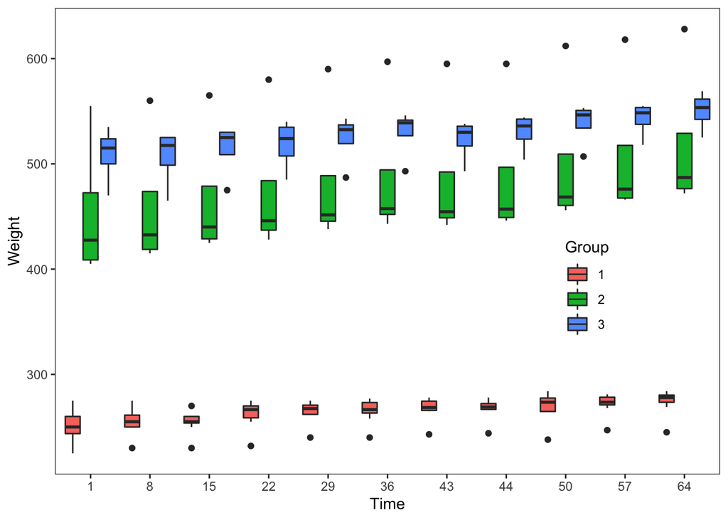

```r
ggplot(rats, aes(x = as.factor(Time), y = Weight, fill = Group)) +
  geom_boxplot(position = position_dodge(width = 0.9)) +
  theme_bw() + theme(panel.grid.major = element_blank(), panel.grid.minor = element_blank()) +
  theme(legend.position = c(0.8,0.4)) +
  scale_x_discrete(name = "Time")
```

### Boxplots of mean summary measures

```r
rats_summary <- rats %>%
  filter(Time > 1) %>%
  group_by(Group, ID) %>%
  summarise( mean=mean(Weight) ) %>%
  ungroup()
```

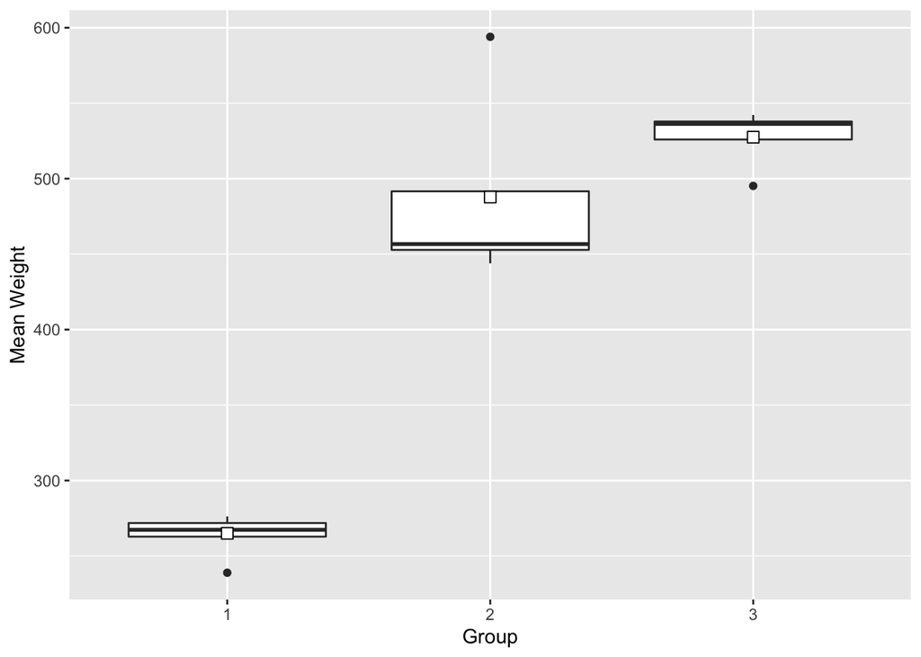

```r
ggplot(rats_summary, aes(x = Group, y = mean)) +
  geom_boxplot() +
  stat_summary(fun = "mean", geom = "point", shape=22, size=3, fill = "white") +
  scale_y_continuous(name = "Mean Weight")
```

### Interpretation of results : Boxplots of mean summary measures

- The diagram indicates that the mean summary measure is more variable in **Group-2** and its distribution in this group is somewhat skew.
- The boxplots of all groups reveal outliers.
- The distribution of **Group-2** and **Group-3** are more skewed where as the distribution in **Group-1** is more balanced.

### Boxplots of mean summary measures without outlier

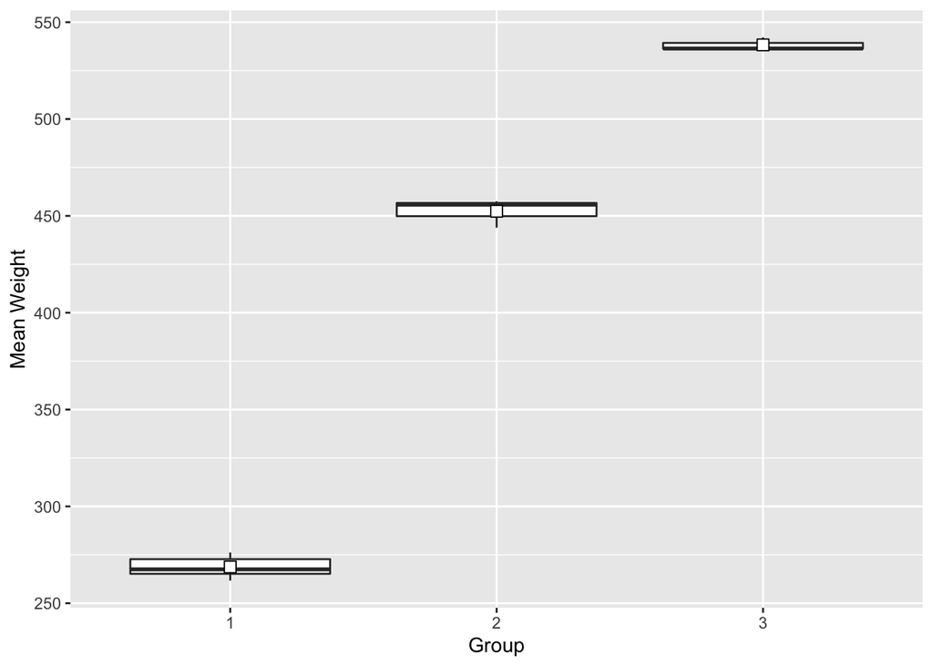

```r
rats_out <- rats_summary %>%
  filter((Group==1 & mean > 250)|(Group==2 & mean < 500)| (Group==3 & mean > 500))


ggplot(rats_out, aes(x = Group, y = mean)) +
  geom_boxplot() +
  stat_summary(fun = "mean", geom = "point", shape=22, size=3, fill = "white") +
  scale_y_continuous(name = "Mean Weight")
```

### Interpretation of results : Boxplots of mean summary measures without outlier

After we have removed the outliers,

- The diagram indicates that the height of all boxes has reduced indicating that variance of all groups goes down. Specially the varaince of **Group-2** is now far reduced.
- The distribution in **Group-1** is now more skewed similarly to The distributions of **Group-2** and **Group-3**.

### Summary results

```r
# Fit the linear model
fit <- lm(mean ~ Group, data = rats_summary)
# summary of the fitted model
summary(fit)
```

```
##
## Call:
## lm(formula = mean ~ Group, data = rats_summary)
##
## Residuals:
##     Min      1Q  Median      3Q     Max
## -43.900 -27.169   2.325   9.069 106.200
##
## Coefficients:
##             Estimate Std. Error t value Pr(>|t|)
## (Intercept)   265.02      12.98  20.419 2.92e-11 ***
## Group2        222.77      22.48   9.909 2.00e-07 ***
## Group3        262.48      22.48  11.675 2.90e-08 ***
## ---
## Signif. codes:  0 '***' 0.001 '**' 0.01 '*' 0.05 '.' 0.1 ' ' 1
##
## Residual standard error: 36.71 on 13 degrees of freedom
## Multiple R-squared:  0.9316, Adjusted R-squared:  0.9211
## F-statistic: 88.52 on 2 and 13 DF,  p-value: 2.679e-08
```

```r
anova(fit)
```

```
## Analysis of Variance Table
##
## Response: mean
##           Df Sum Sq Mean Sq F value    Pr(>F)
## Group      2 238620  119310  88.525 2.679e-08 ***
## Residuals 13  17521    1348
## ---
## Signif. codes:  0 '***' 0.001 '**' 0.01 '*' 0.05 '.' 0.1 ' ' 1
```

### Interpretation of results

- The P-value which corresponds to both **Group-2** and **Group-3** is very small. Therefore, we can conclude there is a strong correlation between the **Weight-mean** variable and both **Group-2** and **Group-3**. P-values are as follows. Group2 -> 2.00e-07 and Group3 -> 2.90e-08.
- For the analysis of variance (ANOVA), To determine whether any of the differences between the means are statistically significant, we can compare the p-value to significance level to assess the null hypothesis. The null hypothesis states that the population means are all equal. Usually, a significance level (denoted as α or alpha) of 0.05 works well. A significance level of 0.05 indicates a 5% risk of concluding that a difference exists when there is no actual difference.
- Here small p-value indicates that a difference exists between groups of rats. The risk here is very small.

## Part 2: Analyses of Chapter 9 of MABS using the BPRS data.

### Graphical overview

```r
# Factor treatment & subject
bprs$treatment <- factor(bprs$treatment)
bprs$subject <- factor(bprs$subject)
str(bprs)
```

```
## 'data.frame':    360 obs. of  5 variables:
##  $ treatment: Factor w/ 2 levels "1","2": 1 1 1 1 1 1 1 1 1 1 ...
##  $ subject  : Factor w/ 20 levels "1","2","3","4",..: 1 2 3 4 5 6 7 8 9 10 ...
##  $ weeks    : chr  "week0" "week0" "week0" "week0" ...
##  $ bprs     : int  42 58 54 55 72 48 71 30 41 57 ...
##  $ week     : int  0 0 0 0 0 0 0 0 0 0 ...
```

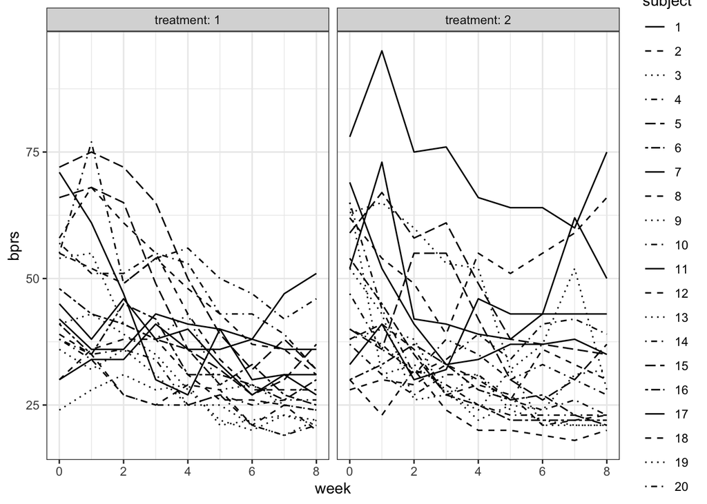

```r
bprs %>%
  ggplot(aes(x = week, y = bprs)) +
  geom_line(aes(linetype = subject)) +
  scale_linetype_manual(values = rep(1:10, times=4)) +
  facet_wrap("treatment", labeller = label_both) +
  theme_bw()
```

### Interpretation of results

- From above plot, we can not observe significant difference between **treatment-1** and **treatment-2**.

### The Linear model

- Here, we fit the data to a linear model with week and treatment as the variables which affects BPRS.

```r
# create a regression model
bprs_lm <- lm(bprs ~ week + treatment, data = bprs)
# print out a summary of the model
summary(bprs_lm)
```

```
##
## Call:
## lm(formula = bprs ~ week + treatment, data = bprs)
##
## Residuals:
##     Min      1Q  Median      3Q     Max
## -22.454  -8.965  -3.196   7.002  50.244
##
## Coefficients:
##             Estimate Std. Error t value Pr(>|t|)
## (Intercept)  46.4539     1.3670  33.982   <2e-16 ***
## week         -2.2704     0.2524  -8.995   <2e-16 ***
## treatment2    0.5722     1.3034   0.439    0.661
## ---
## Signif. codes:  0 '***' 0.001 '**' 0.01 '*' 0.05 '.' 0.1 ' ' 1
##
## Residual standard error: 12.37 on 357 degrees of freedom
## Multiple R-squared:  0.1851, Adjusted R-squared:  0.1806
## F-statistic: 40.55 on 2 and 357 DF,  p-value: < 2.2e-16
```

### Interpretation of results

- **treatment-2** has a higher p-value which indicates independance w.r.t **bprs** variable.
- The P-value which corresponds to both **week** is very small. Therefore, we can conclude there is a strong correlation between the **week** variable and **bprs** variable .

### The Random Intercept Model

- Linear mixed models allow for correlations between the repeated measurements by introducing random effects for subjects.
- Here, we fit the data to a random intercept model with week and treatment as the variables which affects BPRS.
- The random intercept model has two parts. It’s got a fixed part (which is the intercept and the coefficient of the explanatory variable x the explanatory variable) and it’s got a random part.

```r
# access library lme4
library(lme4)
# Create a random intercept model
bprs_ref <- lmer(bprs ~ week + treatment + (1 | subject), data = bprs, REML = FALSE)

# Print the summary of the model
summary(bprs_ref)
```

```
## Linear mixed model fit by maximum likelihood  ['lmerMod']
## Formula: bprs ~ week + treatment + (1 | subject)
##    Data: bprs
##
##      AIC      BIC   logLik deviance df.resid
##   2748.7   2768.1  -1369.4   2738.7      355
##
## Scaled residuals:
##     Min      1Q  Median      3Q     Max
## -3.0481 -0.6749 -0.1361  0.4813  3.4855
##
## Random effects:
##  Groups   Name        Variance Std.Dev.
##  subject  (Intercept)  47.41    6.885
##  Residual             104.21   10.208
## Number of obs: 360, groups:  subject, 20
##
## Fixed effects:
##             Estimate Std. Error t value
## (Intercept)  46.4539     1.9090  24.334
## week         -2.2704     0.2084 -10.896
## treatment2    0.5722     1.0761   0.532
##
## Correlation of Fixed Effects:
##            (Intr) week
## week       -0.437
## treatment2 -0.282  0.000
```

### Interpretation of results

- We can have the attention towards variability (standard deviation) in random-part first.
- Standard deviation of Residual is higher than the standard deviation of subject.
- This higher standard deviation illustrates a higher varaition in residuals.

### Slippery slopes: Random Intercept and Random Slope Model

- Now we can move on to fit the random intercept and random slope model to the data.
- Fitting a random intercept and random slope model allows the linear regression fits for each individual to differ in intercept but also in slope.
- This way it is possible to account for the individual differences in the subjects bprs profiles, but also the effect of time.

```r
# create a random intercept and random slope model
bprs_ref1 <- lmer(bprs ~ week + treatment + (week | subject), data = bprs, REML = FALSE)

# print a summary of the model
summary(bprs_ref1)
```

```
## Linear mixed model fit by maximum likelihood  ['lmerMod']
## Formula: bprs ~ week + treatment + (week | subject)
##    Data: bprs
##
##      AIC      BIC   logLik deviance df.resid
##   2745.4   2772.6  -1365.7   2731.4      353
##
## Scaled residuals:
##     Min      1Q  Median      3Q     Max
## -2.8919 -0.6194 -0.0691  0.5531  3.7976
##
## Random effects:
##  Groups   Name        Variance Std.Dev. Corr
##  subject  (Intercept) 64.8222  8.0512
##           week         0.9609  0.9802   -0.51
##  Residual             97.4305  9.8707
## Number of obs: 360, groups:  subject, 20
##
## Fixed effects:
##             Estimate Std. Error t value
## (Intercept)  46.4539     2.1052  22.066
## week         -2.2704     0.2977  -7.626
## treatment2    0.5722     1.0405   0.550
##
## Correlation of Fixed Effects:
##            (Intr) week
## week       -0.582
## treatment2 -0.247  0.000
```

```r
# perform an ANOVA test on the two models
anova(bprs_ref1, bprs_ref)
```

```
## Data: bprs
## Models:
## bprs_ref: bprs ~ week + treatment + (1 | subject)
## bprs_ref1: bprs ~ week + treatment + (week | subject)
##           npar    AIC    BIC  logLik deviance  Chisq Df Pr(>Chisq)
## bprs_ref     5 2748.7 2768.1 -1369.4   2738.7
## bprs_ref1    7 2745.4 2772.6 -1365.7   2731.4 7.2721  2    0.02636 *
## ---
## Signif. codes:  0 '***' 0.001 '**' 0.01 '*' 0.05 '.' 0.1 ' ' 1
```

### Random Intercept and Random Slope Model with interaction

Finally, we can fit a random intercept and slope model that allows for a treatment × week interaction.

```r
# create a random intercept and random slope model
bprs_ref2 <-lmer(bprs ~ week * treatment + (week | subject), data = bprs, REML = FALSE)

# print a summary of the model
summary(bprs_ref2)
```

```
## Linear mixed model fit by maximum likelihood  ['lmerMod']
## Formula: bprs ~ week * treatment + (week | subject)
##    Data: bprs
##
##      AIC      BIC   logLik deviance df.resid
##   2744.3   2775.4  -1364.1   2728.3      352
##
## Scaled residuals:
##     Min      1Q  Median      3Q     Max
## -3.0512 -0.6271 -0.0768  0.5288  3.9260
##
## Random effects:
##  Groups   Name        Variance Std.Dev. Corr
##  subject  (Intercept) 64.9964  8.0620
##           week         0.9687  0.9842   -0.51
##  Residual             96.4707  9.8220
## Number of obs: 360, groups:  subject, 20
##
## Fixed effects:
##                 Estimate Std. Error t value
## (Intercept)      47.8856     2.2521  21.262
## week             -2.6283     0.3589  -7.323
## treatment2       -2.2911     1.9090  -1.200
## week:treatment2   0.7158     0.4010   1.785
##
## Correlation of Fixed Effects:
##             (Intr) week   trtmn2
## week        -0.650
## treatment2  -0.424  0.469
## wek:trtmnt2  0.356 -0.559 -0.840
```

```r
# perform an ANOVA test on the two models
anova(bprs_ref2, bprs_ref1)
```

```
## Data: bprs
## Models:
## bprs_ref1: bprs ~ week + treatment + (week | subject)
## bprs_ref2: bprs ~ week * treatment + (week | subject)
##           npar    AIC    BIC  logLik deviance  Chisq Df Pr(>Chisq)
## bprs_ref1    7 2745.4 2772.6 -1365.7   2731.4
## bprs_ref2    8 2744.3 2775.4 -1364.1   2728.3 3.1712  1    0.07495 .
## ---
## Signif. codes:  0 '***' 0.001 '**' 0.01 '*' 0.05 '.' 0.1 ' ' 1
```

### Interpretation of results

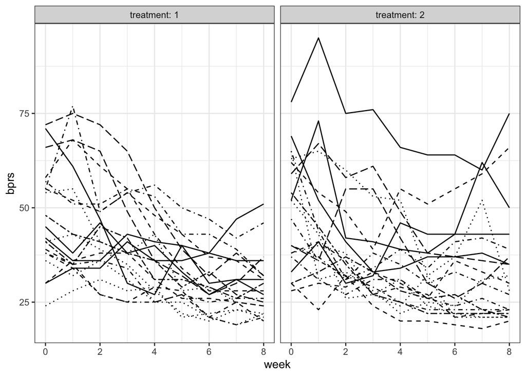

```r
# Create a vector of the fitted values
Fitted <- fitted(bprs_ref2)

# Create a new column fitted to BPRS
bprs <- bprs %>%
  mutate(Fitted)

ggplot(bprs,aes(x = week, y = bprs)) +
  geom_line(aes(linetype = subject)) +
  scale_linetype_manual(values = rep(1:10, times=4)) +
  facet_wrap("treatment", labeller = label_both) +
  theme_bw() +
  theme(legend.position = "none")
```

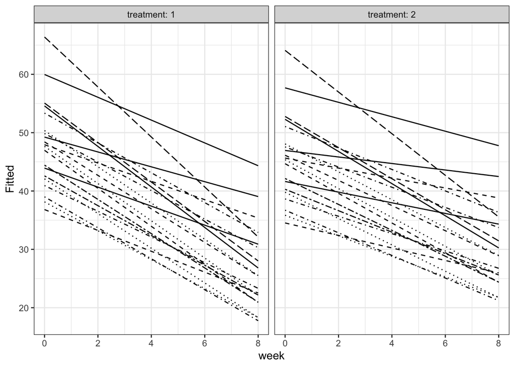

```r
ggplot(bprs,aes(x = week, y = Fitted)) +
  geom_line(aes(linetype = subject)) +
  scale_linetype_manual(values = rep(1:10, times=4)) +
  facet_wrap("treatment", labeller = label_both) +
  theme_bw() +
  theme(legend.position = "none")
```

### Interpretation of results

- As seen in above plots, we do not see a significant difference to distinguish between **treatment-1** and **treatment-2** .

That’s the end of course! Thanks to everyone!